# SECTION 1: INTRODUCTION & PROBLEM STATEMENT

## 1.1 Introduction

Gradient‐based optimization algorithms play a central role in training machine learning models. However, standard methods such as vanilla Gradient Descent or SGD rely on a single global learning rate, causing difficulties when dealing with heterogeneous or sparse feature spaces. The Adagrad (Adaptive Gradient) algorithm was proposed to address this issue by adapting the learning rate for each parameter individually based on historical gradient information.

Unlike fixed-rate optimizers, Adagrad automatically scales the learning rate according to how frequently a parameter is updated:

- Parameters with frequent updates receive progressively smaller learning rates,
- Parameters with infrequent updates retain larger learning rates and therefore continue learning effectively.

This adaptive behavior makes Adagrad particularly well-suited for problems involving sparse features, such as natural language processing or recommendation systems.

The goal of this report is to examine the motivation behind Adagrad, describe its mathematical formulation, analyze its advantages and limitations, and discuss its impact on optimization in high-dimensional sparse settings.

## 1.2 Motivation: Sparse Features

In many tasks such as **natural language processing**, data are often sparse: most values are zero and only a small subset of features are active. Models like *bag-of-words* and *one-hot encoding* may have tens of thousands of features, but each sample only activates a few.

### 1.2.1 Global learning rate decay is not suitable

If using a decaying learning rate globally:

$$\eta_t = \frac{\eta_0}{\sqrt{t}}$$

then a parameter corresponding to a rare feature will only be updated when that feature appears. If it first appears at a large step $t$, the learning rate may already be too small.

### 1.2.2 Example of Global Decay Calculation

**Assume:**

- Initial learning rate: $\eta_0 = 0.1$
- A rare feature appears for the first time at step $t = 1000$
- Gradient at that step: $g_{1000} = 0.5$

**Calculate learning rate at $t = 1000$ using global decay:**

$$\eta_{1000} = \frac{\eta_0}{\sqrt{1000}} = \frac{0.1}{31.6228} \approx 0.00316$$

**Update weight (initial weight $w_0 = 0$):**

$$w_{1000} = w_0 - \eta_{1000}g_{1000} = 0 - 0.00316 \times 0.5 \approx -0.00158$$

**Observation:** The weight change is extremely small, even though the feature may be important. This illustrates the limitation of using a globally decaying learning rate for sparse features: rare features get almost no update when they first appear at large $t$.

## 1.3 Naive Solution and Its Limitations

A simple idea is to track how many times each feature appears. Let $s(i, t)$ be the number of times feature $i$ has been activated until time $t$. Then:

$$\eta_{i,t} = \frac{\eta_0}{\sqrt{s(i, t) + c}}$$

with $c > 0$ to avoid division by zero.

### 1.3.1 Example of naive solution

Assume the following:

- Initial weight: $w_0 = 0$
- Initial learning rate: $\eta_0 = 0.1$
- Small constant: $c = 10^{-8}$
- Gradient values observed at each step: $g_1 = 0.5, g_2 = 0.1, g_3 = 0.3$

**a. The feature appears for the first time: $s(i, 1) = 1$.**

$$\eta_{i,1} = \frac{0.1}{\sqrt{1 + 10^{-8}}} \approx 0.1$$

Update the weight: $$w_1 = w_0 - \eta_{i,1}g_1 = 0 - 0.1 * 0.5 = -0.05$$

**b. The feature appears for the second time: $s(i, 2) = 2$.**

$$\eta_{i,2} = \frac{0.1}{\sqrt{2 + 10^{-8}}} \approx 0.0707$$

Update the weight: $$w_2 = w_1 - \eta_{i,2}g_2 = -0.05 - 0.0707 * 0.1 \approx -0.0571$$

**c. The feature appears for the third time: $s(i, 3) = 3$.**

$$\eta_{i,3} = \frac{0.1}{\sqrt{3 + 10^{-8}}} \approx 0.0577$$

Update the weight: $$w_3 = w_2 - \eta_{i,3}g_3 = -0.0571 - 0.0577 * 0.3 \approx -0.0744$$

> **Explanation:** At each step, the learning rate decreases slightly as the feature appears more often. This ensures that rare features are updated with a larger step initially, while frequent features gradually get smaller updates. However, this naive approach still ignores the magnitude of gradients over time.

### 1.3.2 Limitations

1. **Ignores gradient magnitude:** two occurrences with gradients $0.001$ and $10$ are treated equally.
2. **Cannot handle well** cases where small gradient occurs often or large gradient occurs rarely.
3. **Depends on the definition** of “one occurrence,” introducing extra hyperparameters.

> **Hence:** A more sophisticated mechanism is needed: consider not only the number of appearances but also the gradient magnitude.

# SECTION 2: ALGORITHM & MECHANISM

## 2.1 Adagrad Mechanism: Accumulated Squared Gradients

### 2.1.1. From a Simple Counter to Squared Gradients

Consider training a model where each parameter corresponds to a feature. Some features appear very often, others are rare. A naive idea is to keep a counter of how many times each feature has appeared up to step $t$:

$$s(i, t) = \text{number of times feature } i \text{ has appeared up to step } t$$

Then define a coordinate-wise learning rate:

$$\eta_{i,t} = \frac{\eta}{\sqrt{s(i, t)}}$$

So, if a feature appears many times (large $s(i, t)$), its learning rate becomes smaller; if it appears rarely (small $s(i, t)$), its learning rate remains larger. This already captures some intuition, but it has a serious limitation:

- It is binary: either "appeared" or "not appeared".
- It does not distinguish between small gradient values (feature present but not important) and large gradient values (feature strongly affects the loss).
- One must choose an arbitrary threshold to decide what counts as an "appearance".

Adagrad improves on this by replacing this crude counter with a sum of squared gradients.

For each coordinate $i$, Adagrad maintains:

$$s(i, t + 1) = s(i, t) + (\partial_i f(x_t))^2$$

Here:

- $\partial_i f(x_t)$ is the gradient of the loss with respect to parameter $x_i$ at step $t$.
- $s(i, t)$ is no longer just "how many times feature $i$ appeared", but rather "how large the gradients of coordinate $i$ have been over time".

> **Core idea:** Instead of counting appearances, Adagrad accumulates the squared size of gradients for each parameter.

### 2.1.2. Adaptive Learning Rate per Coordinate

Given the accumulated squared gradients $s(i, t)$, Adagrad defines a **per-coordinate learning rate**:

$$\eta_{i,t} = \frac{\eta}{\sqrt{s(i, t) + \epsilon}}$$

**Where:**

- $\eta$: The base learning rate chosen by the user (hyperparameter).
- $\epsilon$: A small constant (e.g., $10^{-8}$) added to avoid division by zero (numerical stability).

**The parameter update rule becomes:**

$$x_i^{(t+1)} = x_i^{(t)} - \eta_{i,t} \partial_i f(x_t) = x_i^{(t)} - \frac{\eta}{\sqrt{s(i, t) + \epsilon}} \partial_i f(x_t)$$

> **Conclusion:** Each parameter $x_i$ has its own effective learning rate, which shrinks as the sum of its past squared gradients grows. Frequent features (large accumulated gradients) get small updates, while rare features (small accumulated gradients) get larger updates.

### 2.1.3. Analysis of the Update Rule

**1. No Need for Arbitrary Thresholds**

In the naive counter approach, one must decide: *"How large must a gradient be to count as an appearance?"*. This is arbitrary and problem-dependent.

**With Adagrad:**

- Every gradient, no matter how small, contributes to $s(i, t)$.
- Larger gradients naturally contribute more (because they are squared).
- There is no binary decision ("count" vs "don't count") and no threshold hyperparameter to tune.

**2. The algorithm automatically weighs gradients according to their size.**

**3. Automatic Scaling According to Gradient Magnitude**

The accumulated sum $s(i, t) = \sum_{\tau=1}^t (\partial_i f(x_\tau))^2$ grows:

- **Fast** if gradients for coordinate $i$ are large or frequent.
- **Slow** if gradients are small or rare.

**4. Because the effective learning rate is $\eta_{i,t} = \frac{\eta}{\sqrt{s(i, t) + \epsilon}}$, this means:**

- **For "noisy" or frequently changing coordinates** (large or frequent gradients): $s(i, t)$ becomes large $\rightarrow$ $\sqrt{s(i, t)}$ is large, so $\eta_{i,t}$ becomes small. These coordinates are slowed down, avoiding overshooting.
- **For "quiet" or rare coordinates** (small or infrequent gradients): $s(i, t)$ stays small, so $\eta_{i,t}$ remains relatively large. These coordinates keep larger steps, allowing them to learn even with sparse updates.

> **Summary:** Adagrad’s “accumulated squared gradient” mechanism replaces a rough frequency counter with a smooth, magnitude-sensitive history for each parameter, giving automatic, coordinate-wise learning rate adaptation.

# 2.2 Adagrad and the Concept of Preconditioning

## 2.2.1 Quadratic Convex Optimization and Condition Number

Consider a quadratic convex function:

$$f(x) = \frac{1}{2} x^\top Q x + c^\top x + b, \quad Q \succ 0$$

**Here:**

- $x \in \mathbb{R}^d$ is the parameter vector.
- $Q$ is a symmetric positive definite matrix (the Hessian).
- $c$ and $b$ are constants.

**Properties of this function:**

- **The gradient:** $\nabla f(x) = Qx + c$
- **The Hessian** (matrix of second derivatives): $\nabla^2 f(x) = Q$
- **Geometry:** The shape of the level sets (contours) of $f$ is an ellipsoid defined by $Q$.

The condition number of $Q$ is defined as:

$$\kappa(Q) = \frac{\lambda_{\max}(Q)}{\lambda_{\min}(Q)}$$

where $\lambda_{\max}$ and $\lambda_{\min}$ are the largest and smallest eigenvalues of $Q$.

**Intuitive Interpretation:**

1. **If $\kappa(Q) \approx 1$:**
   - All eigenvalues are similar.
   - The level sets are close to circles (spheres).
   - Gradient descent moves smoothly and converges fast.
2. **If $\kappa(Q)$ is large:**
   - The eigenvalues are very different.
   - The level sets are very elongated ellipsoids.
   - Gradient descent "zigzags": it moves quickly along steep directions (large eigenvalues) but slowly along flat ones (small eigenvalues), leading to slow convergence.

> Thus, $\kappa(Q)$ measures how "difficult" the optimization problem is for standard gradient descent.

### 2.2.2 Preconditioning: Changing Coordinates to Improve Conditioning

**Preconditioning** means applying a linear transformation to the variables to improve the condition number and make the optimization landscape "rounder" (closer to a sphere).

**1. Change of Variables**

Define a new variable $y$: $$y = P^{1/2}x$$

where $P \succ 0$ is the **preconditioning matrix**. In terms of $y$, the function becomes:

$$f(x) = f(P^{-1/2}y) = \frac{1}{2}y^\top (P^{-1/2}QP^{-1/2})y + (\text{linear terms})$$

**2. The New Hessian**

The Hessian matrix of the transformed function is:

$$\tilde{Q} = P^{-1/2}QP^{-1/2}$$

**3. The Strategy**

If $P$ is chosen well, the condition number $\kappa(\tilde{Q})$ can be much smaller than the original $\kappa(Q)$, making gradient descent converge much faster.

- **Ideal Choice:** Theoretically, the best choice is $P = Q$. Then: $$\tilde{Q} = Q^{-1/2}Q Q^{-1/2} = I$$ The condition number becomes **1**, and the problem becomes perfectly conditioned (the contours are spheres). However, computing and inverting the full matrix $Q$ in high dimensions is **too expensive**.
- **Practical Alternative (Diagonal Preconditioning):** Instead of the full matrix, we use only the diagonal elements:
  - Take $M = \text{diag}(Q)$ (matrix with only diagonal entries of $Q$).
  - Use $M^{-1/2}$ as the preconditioner: $$\tilde{Q} = M^{-1/2}QM^{-1/2}$$

> **Key Insight:** This diagonal preconditioning is cheap to compute and works very well when the main anisotropy (stretching) of the function is aligned with the coordinate axes. **Adagrad approximates this diagonal preconditioning** by using accumulated gradients to estimate the curvature along each axis.

### 2.2.3 Viewing Adagrad as Time-Varying Diagonal Preconditioning

Now connect the concept of preconditioning to Adagrad.

**1. Vector Form of Adagrad**

We can write the Adagrad accumulator in vector notation:

- **Accumulator:** $$s_t = s_{t-1} + g_t \odot g_t$$ where $g_t = \nabla f(x_t)$ and $\odot$ denotes element-wise multiplication.
- **Diagonal Matrix:** Let $D_t = \text{diag}(s_t + \epsilon)$ be a diagonal matrix with entries $s_t + \epsilon$ on the diagonal.
- **Update Rule:** The Adagrad update rule can be rewritten as: $$x_{t+1} = x_t - \eta D_t^{-1/2} g_t$$

> **Observation:** This is exactly **Gradient Descent with a diagonal preconditioner** $D_t^{-1/2}$ that changes over time.

**2. Connection to the Hessian**

Near the optimum $x^*$ of a quadratic function, the gradient behaves like $g_t \approx Q(x_t - x^*)$. In coordinates where the problem is close to axis-aligned:

- Directions with large curvature (large diagonal entries of Hessian $Q$) tend to produce larger gradients.
- Directions with small curvature (small diagonal entries) tend to produce smaller gradients.

Over time, the accumulated squared gradients $s_t$ approximate (up to scaling) the **diagonal of** $Q^2$. Therefore, taking $D_t^{-1/2}$ is similar to using $\text{diag}(Q)^{-1/2}$ as a preconditioner.

**3. Final Interpretation**

So Adagrad can be interpreted as:

- **Stochastic Gradient Descent + Diagonal Preconditioning**
- Where the preconditioner is learned online from the gradients instead of being computed from the Hessian $Q$ explicitly.

> This explains why Adagrad dramatically improves convergence on problems where the main stretching of the landscape is roughly axis-aligned: it is implicitly **"rounding" the optimization landscape** in each coordinate.

## 2.3 Gradient as a Proxy for the Hessian

### 2.3.1 Computing the Hessian Is Not Feasible in Deep Learning

The Hessian of a function $f: \mathbb{R}^d \rightarrow \mathbb{R}$ is a $d \times d$ matrix. In deep learning, the number of parameters $d$ is often:

- Hundreds of thousands,
- Millions,
- Or even billions.

Storing a full $d \times d$ matrix:

- Requires memory on the order of $O(d^2)$.
- For $d = 10^6$, this is $10^{12}$ entries—completely impractical.

Computing and using the full Hessian (e.g., in Newton’s method or full-matrix preconditioning) is therefore **impossible in practice**:

- Time complexity is too high.
- Memory requirement is too large.
- Implementation is too complex and unstable with noisy mini-batch gradients.

> So, in deep learning, one must use **first-order information only** (gradients), but still wants some of the benefits of second-order methods (which use the Hessian).

### 2.3.2 The Clever Idea: Using Gradient Statistics as a Proxy

**For a quadratic function:**

$$f(x) = \frac{1}{2} x^\top Q x + c^\top x + b$$

the gradient is:

$$g(x) = Qx + c$$

Near the optimum $x^*$, this is approximately:

$$g(x) \approx Q(x - x^*)$$

**Consider one coordinate $i$:**

- If the **curvature (roughly $Q_{ii}$)** is **large**, then a small change in $x_i$ produces a large change in the gradient $g_i$.
- Over the course of training (different mini-batches, different steps), a high-curvature coordinate tends to have **larger gradients** (in magnitude) or **higher variability**.

**Adagrad’s Approximation Strategy**

Adagrad **does not compute** the Hessian $Q$. Instead, it only observes the gradients $g_t$ over time and accumulates:

$$s(i, t) = \sum_{\tau=1}^t (g_{\tau, i})^2$$

This quantity captures information about:

- How **large** the gradients for coordinate $i$ are on average.
- How **sensitive** the loss is to changes in parameter $x_i$.

In other words, $s(i, t)$ is a **cheap, noisy proxy** for the diagonal of some function of the Hessian (roughly larger if curvature is higher).

**Thus:**

- The **Hessian diagonal** tells us how steep the landscape is along each coordinate.
- The **accumulated squared gradients** in Adagrad approximate that information *without ever forming the Hessian*.

> **Key Insight:** Adagrad uses the **magnitude (variance) of gradients** as a **proxy for the diagonal of the Hessian**.

### 2.3.3 Adagrad in Deep Learning

In deep learning contexts:

- Optimization uses **stochastic gradients** from mini-batches.
- Exact second-order information is noisy and expensive.
- However, **gradients are already being computed** at each step.

Adagrad leverages this by:

1. **Re-using gradients** to build a running estimate $s(i, t)$ of how "active" each parameter is.
2. Interpreting this as rough curvature information per coordinate.
3. Scaling learning rates accordingly.

So, instead of:

- **Computing a full Hessian:** Costly $O(d^2)$ memory and $O(d^3)$ time to invert/factorize.
- **Adagrad:**
  - Stores only a vector $s_t \in \mathbb{R}^d$ (linear cost $O(d)$).
  - Updates it with simple element-wise operations (very cheap).
  - Achieves some of the benefits of **Hessian-based preconditioning** by using gradient history as an **implicit, approximate curvature signal**.

## 2.4 The Adagrad Algorithm

From section 2.2 and 2.3 on Preconditioning, we have seen the idea of adjusting learning rates per coordinate and using a diagonal matrix to scale the parameter space. Now we formalize the Adagrad algorithm - a practical implementation of that idea.

### 2.4.1 The Algorithm

We use the variable $\mathbf{s}_t$ to accumulate the variance of past gradients as follows:

$$ \begin{aligned} \mathbf{g}_t & = \partial_{\mathbf{w}} l(y_t, f(\mathbf{x}_t, \mathbf{w})), \\ \mathbf{s}_t & = \mathbf{s}_{t-1} + \mathbf{g}_t^2, \\ \mathbf{w}_t & = \mathbf{w}_{t-1} - \frac{\eta}{\sqrt{\mathbf{s}_t + \epsilon}} \cdot \mathbf{g}_t. \end{aligned} \tag{12.7.5} $$

**Important note:** All operations are performed **element-wise**:

- $\mathbf{g}_t^2$ means $[g_{t,1}^2, g_{t,2}^2, \ldots, g_{t,d}^2]$
- $\sqrt{\mathbf{s}_t + \epsilon}$ means $[\sqrt{s_{t,1} + \epsilon}, \sqrt{s_{t,2} + \epsilon}, \ldots, \sqrt{s_{t,d} + \epsilon}]$
- $\frac{\eta}{\sqrt{\mathbf{s}_t + \epsilon}} \cdot \mathbf{g}_t$ means $\left[\frac{\eta}{\sqrt{s_{t,1} + \epsilon}} \cdot g_{t,1}, \frac{\eta}{\sqrt{s_{t,2} + \epsilon}} \cdot g_{t,2}, \ldots, \frac{\eta}{\sqrt{s_{t,d} + \epsilon}} \cdot g_{t,d}\right]$

**Parameters:**

- $\eta$ - learning rate
- $\epsilon$ - small additive constant (typically $10^{-8}$) to avoid division by zero
- **Initialization:** $\mathbf{s}_0 = \mathbf{0}$

### 2.4.2 Explaination of Each Step

**Step 1: Compute gradient**

$$\mathbf{g}_t = \partial_{\mathbf{w}} l(y_t, f(\mathbf{x}_t, \mathbf{w}))$$ The gradient at the current point indicates the direction of steepest change.

**Step 2: Accumulate squared gradients**

Each coordinate "remembers" its gradient history:

- If gradient is **large** many times → $\mathbf{s}_t$ accumulates large values → effective lr becomes **small**
- If gradient is **small** → $\mathbf{s}_t$ accumulates slowly → effective lr remains relatively **large**

**Step 3: Update parameters**

Update with learning rate adjusted per coordinate:

- Each coordinate has its own lr: $\frac{\eta}{\sqrt{s_{t,i} + \epsilon}}$
- Learning rate decreases as $s_{t,i}$ increases

### 2.4.3 Design Principles

**1. Per-coordinate adaptation**

In many problems, different coordinates have different "sensitivities". Coordinates that **change strongly** (large gradients) need **small** learning rates to avoid overshooting, while coordinates that **change weakly** (small gradients) need **large** learning rates to learn faster. Adagrad adjusts automatically without manual tuning for each parameter.

**2. Connection to Preconditioning**

This is an application of **automatic preconditioning** - Adagrad uses gradient magnitude as a proxy for the diagonal of the Hessian, helping to "flatten" the objective function without computing eigenvalues. Each step is equivalent to gradient descent with a diagonal scaling matrix $D_t = \text{diag}(1/\sqrt{s_t})$.

**3. Computational Cost**

Like momentum, we track an auxiliary variable $\mathbf{s}_t \in \mathbb{R}^d$ with $O(d)$ storage - negligible compared to computing the full Hessian's $O(d^2)$ cost. The learning rate decreases as $O(1/\sqrt{t})$: stable for convex problems but may decrease too quickly for non-convex/deep learning tasks, requiring variants like RMSProp or Adam.

## 2.5 Applications of Adagrad

Adagrad is particularly effective in domains with **sparse data** or features with **varying frequencies**.

1. **Natural Language Processing (NLP)**
   - *Example:* Text classification using *bag-of-words*. Rare words still learn meaningful weights thanks to Adagrad.
2. **Computational Advertising**
   - CTR prediction models use user IDs, ad IDs, and queries—mostly sparse features. Adagrad prevents rare ads from being “ignored.”
3. **Recommender Systems**
   - Many users or products have few interactions. Adagrad ensures embeddings are sufficiently trained.

# SECTION 3: COMPUTATION & IMPLEMENTATION

## 3.1. Step-by-Step Calculation Example

In this section, we demonstrate Adagrad's behavior on two different objective functions:

- **Function 1 (Axis-aligned)**: Variables are independent
- **Function 2 (Rotated)**: Variables are strongly correlated

### Case 1: Axis-Aligned Function

#### **Objective Function**

$$f_1(\mathbf{x}) = 0.1x_1^2 + 2x_2^2$$

This is an axis-aligned elliptic paraboloid where the variables $x_1$ and $x_2$ are independent.

#### **Finding the Critical Point (Theoretical Solution)**

Solve the system $\nabla f_1 = \mathbf{0}$:

$$ \begin{cases} \frac{\partial f_1}{\partial x_1} = 0.2x_1 = 0 \\ \frac{\partial f_1}{\partial x_2} = 4x_2 = 0 \end{cases} $$

$$\Rightarrow x_1 = 0, \quad x_2 = 0$$

Conclusion: Minimum at $(0, 0)$ with $f_1(0, 0) = 0$

#### **Setup for Adagrad**

Parameters are set as follows:

- Starting point: $\mathbf{x}^{(0)} = (x_1^{(0)}, x_2^{(0)}) = (5, 3)$
- Learning rate: $\eta = 0.4$
- Epsilon: $\varepsilon = 10^{-8}$
- Gradient formula: $\nabla f_1 = \begin{bmatrix} 0.2x_1 \\ 4x_2 \end{bmatrix}$

#### **Step-by-Step Calculations for Function 1**

**1. Step 1 (t=1)**

Current: $\mathbf{x}^{(0)} = (5.0, 3.0)$

a. Compute gradient: $$\mathbf{g}_1 = \begin{bmatrix} 0.2 \times 5 \\ 4 \times 3 \end{bmatrix} = \begin{bmatrix} 1.0 \\ 12.0 \end{bmatrix}$$

b. Update accumulator $\mathbf{s}$: $$\mathbf{s}_1 = \begin{bmatrix} 0 \\ 0 \end{bmatrix} + \begin{bmatrix} 1.0^2 \\ 12.0^2 \end{bmatrix} = \begin{bmatrix} 1.0 \\ 144.0 \end{bmatrix}$$

c. Compute effective learning rate:

- For $x_1$: $\frac{\eta}{\sqrt{s_1^{(1)} + \varepsilon}} = \frac{0.4}{\sqrt{1.0}} = 0.4$
- For $x_2$: $\frac{\eta}{\sqrt{s_2^{(1)} + \varepsilon}} = \frac{0.4}{\sqrt{144.0}} = \frac{0.4}{12} \approx 0.0333$

d. Compute update: $$\Delta \mathbf{x}_1 = \eta_{eff} \odot \mathbf{g}_1 = \begin{bmatrix} 0.4 \times 1.0 \\ 0.0333 \times 12.0 \end{bmatrix} = \begin{bmatrix} 0.4 \\ 0.4 \end{bmatrix}$$

e. Update parameters: $$\mathbf{x}^{(1)} = \mathbf{x}^{(0)} - \Delta \mathbf{x}_1 = \begin{bmatrix} 5.0 - 0.4 \\ 3.0 - 0.4 \end{bmatrix} = \begin{bmatrix} 4.6 \\ 2.6 \end{bmatrix}$$

Function value: $f_1(4.6, 2.6) = 0.1(4.6)^2 + 2(2.6)^2 = 2.116 + 13.52 = 15.636$

**2. Step 2 (t=2)**

Current: $\mathbf{x}^{(1)} = (4.6, 2.6)$

a. Gradient: $$\mathbf{g}_2 = \begin{bmatrix} 0.2 \times 4.6 \\ 4 \times 2.6 \end{bmatrix} = \begin{bmatrix} 0.92 \\ 10.4 \end{bmatrix}$$

b. Update $\mathbf{s}$: $$\mathbf{s}_2 = \begin{bmatrix} 1.0 \\ 144.0 \end{bmatrix} + \begin{bmatrix} 0.8464 \\ 108.16 \end{bmatrix} = \begin{bmatrix} 1.8464 \\ 252.16 \end{bmatrix}$$

c. Effective learning rate:

- For $x_1$: $\frac{0.4}{\sqrt{1.8464}} \approx 0.2944$
- For $x_2$: $\frac{0.4}{\sqrt{252.16}} \approx 0.0252$

d. Update: $$\Delta \mathbf{x}_2 = \begin{bmatrix} 0.2944 \times 0.92 \\ 0.0252 \times 10.4 \end{bmatrix} \approx \begin{bmatrix} 0.2709 \\ 0.2621 \end{bmatrix}$$

$$\mathbf{x}^{(2)} = \begin{bmatrix} 4.6 - 0.2709 \\ 2.6 - 0.2621 \end{bmatrix} = \begin{bmatrix} 4.3291 \\ 2.3379 \end{bmatrix}$$

Function value: $f_1(4.3291, 2.3379) \approx 12.817$

**3. Step 3 (t=3)**

Current: $\mathbf{x}^{(2)} \approx (4.3291, 2.3379)$

a. Gradient: $$\mathbf{g}_3 = \begin{bmatrix} 0.8658 \\ 9.3516 \end{bmatrix}$$

b. Update $\mathbf{s}$: $$\mathbf{s}_3 = \begin{bmatrix} 1.8464 + 0.7496 \\ 252.16 + 87.4524 \end{bmatrix} = \begin{bmatrix} 2.596 \\ 339.6124 \end{bmatrix}$$

c. Effective learning rate: $$\eta_{eff} \approx \begin{bmatrix} 0.2482 \\ 0.0217 \end{bmatrix}$$

d. Update: $$\mathbf{x}^{(3)} \approx \begin{bmatrix} 4.1142 \\ 2.1350 \end{bmatrix}$$

Function value: $f_1(4.1142, 2.1350) \approx 10.805$

#### **Observations for Function 1 (Axis-aligned)**

1. **Effective LR adapts per coordinate:**
   - $x_1$ has small gradient (0.2 coefficient) → larger effective LR maintained
   - $x_2$ has large gradient (4.0 coefficient) → smaller effective LR
2. **Convergence is balanced:**
   - Both coordinates move toward 0 smoothly
   - The per-coordinate adaptation works perfectly because variables are independent
3. **Updates align with coordinate axes:**
   - Gradient always points along $x_1$ or $x_2$ axis
   - Adagrad's diagonal scaling is ideal for this structure

### Case 2: Rotated Function

#### **Objective Function**

$$f_2(\mathbf{x}) = 0.1(x_1 + x_2)^2 + 2(x_1 - x_2)^2$$

This is a **rotated elliptic paraboloid** where variables $x_1$ and $x_2$ are strongly correlated.

#### **Finding the Critical Point**

Expand the function: $$f_2(\mathbf{x}) = 0.1(x_1^2 + 2x_1x_2 + x_2^2) + 2(x_1^2 - 2x_1x_2 + x_2^2)$$ $$= 0.1x_1^2 + 0.2x_1x_2 + 0.1x_2^2 + 2x_1^2 - 4x_1x_2 + 2x_2^2$$ $$= 2.1x_1^2 - 3.8x_1x_2 + 2.1x_2^2$$

Solve $\nabla f_2 = \mathbf{0}$:

$$ \begin{cases} \frac{\partial f_2}{\partial x_1} = 4.2x_1 - 3.8x_2 = 0 \\ \frac{\partial f_2}{\partial x_2} = -3.8x_1 + 4.2x_2 = 0 \end{cases} $$

From the first equation: $x_1 = \frac{3.8}{4.2}x_2 \approx 0.905x_2$

Substituting into the second equation yields $x_1 = x_2 = 0$.

**Conclusion:** Minimum at $(0, 0)$ with $f_2(0, 0) = 0$

#### **Setup for Adagrad**

Parameters:

- Starting point: $\mathbf{x}^{(0)} = (5, 3)$ (same as Function 1)
- Learning rate: $\eta = 0.4$
- Epsilon: $\varepsilon = 10^{-8}$
- Gradient formula: $\nabla f_2 = \begin{bmatrix} 4.2x_1 - 3.8x_2 \\ -3.8x_1 + 4.2x_2 \end{bmatrix}$

#### **Step-by-Step Calculations for Function 2**

**1. Step 1 (t=1)**

Current: $\mathbf{x}^{(0)} = (5.0, 3.0)$

a. Compute gradient: $$\mathbf{g}_1 = \begin{bmatrix} 4.2 \times 5 - 3.8 \times 3 \\ -3.8 \times 5 + 4.2 \times 3 \end{bmatrix} = \begin{bmatrix} 21.0 - 11.4 \\ -19.0 + 12.6 \end{bmatrix} = \begin{bmatrix} 9.6 \\ -6.4 \end{bmatrix}$$

b. Update $\mathbf{s}$: $$\mathbf{s}_1 = \begin{bmatrix} 0 \\ 0 \end{bmatrix} + \begin{bmatrix} 92.16 \\ 40.96 \end{bmatrix} = \begin{bmatrix} 92.16 \\ 40.96 \end{bmatrix}$$

c. Effective learning rate:

- For $x_1$: $\frac{0.4}{\sqrt{92.16}} = \frac{0.4}{9.6} \approx 0.0417$
- For $x_2$: $\frac{0.4}{\sqrt{40.96}} = \frac{0.4}{6.4} = 0.0625$

d. Update: $$\Delta \mathbf{x}_1 = \begin{bmatrix} 0.0417 \times 9.6 \\ 0.0625 \times (-6.4) \end{bmatrix} = \begin{bmatrix} 0.4 \\ -0.4 \end{bmatrix}$$

$$\mathbf{x}^{(1)} = \begin{bmatrix} 5.0 - 0.4 \\ 3.0 - (-0.4) \end{bmatrix} = \begin{bmatrix} 4.6 \\ 3.4 \end{bmatrix}$$

Function value: $f_2(4.6, 3.4) = 0.1(8.0)^2 + 2(1.2)^2 = 6.4 + 2.88 = 9.28$

**2. Step 2 (t=2)**

Current: $\mathbf{x}^{(1)} = (4.6, 3.4)$

a. Gradient: $$\mathbf{g}_2 = \begin{bmatrix} 4.2 \times 4.6 - 3.8 \times 3.4 \\ -3.8 \times 4.6 + 4.2 \times 3.4 \end{bmatrix} = \begin{bmatrix} 6.4 \\ -3.2 \end{bmatrix}$$

b. Update $\mathbf{s}$: $$\mathbf{s}_2 = \begin{bmatrix} 92.16 + 40.96 \\ 40.96 + 10.24 \end{bmatrix} = \begin{bmatrix} 133.12 \\ 51.2 \end{bmatrix}$$

c. Effective learning rate:

- For $x_1$: $\frac{0.4}{\sqrt{133.12}} \approx 0.0347$
- For $x_2$: $\frac{0.4}{\sqrt{51.2}} \approx 0.0559$

d. Update: $$\mathbf{x}^{(2)} \approx \begin{bmatrix} 4.6 - 0.222 \\ 3.4 - (-0.179) \end{bmatrix} = \begin{bmatrix} 4.378 \\ 3.579 \end{bmatrix}$$

**3. Step 3 (t=3)**

Current: $\mathbf{x}^{(2)} \approx (4.378, 3.579)$

a. Gradient: $$\mathbf{g}_3 \approx \begin{bmatrix} 4.785 \\ -1.393 \end{bmatrix}$$

b. Update $\mathbf{s}$: $$\mathbf{s}_3 \approx \begin{bmatrix} 156.01 \\ 53.14 \end{bmatrix}$$

c. Update: $$\mathbf{x}^{(3)} \approx \begin{bmatrix} 4.225 \\ 3.655 \end{bmatrix}$$

### Explaination Why is Function 2 More Difficult for Adagrad

**1. The Root Cause: Coordinate System Mismatch**

The fundamental challenge with Function 2 stems from a mismatch between the coordinate system we're using ($x_1, x_2$) and the natural geometry of the function.

**Function 2 expanded:** $$f_2(\mathbf{x}) = 2.1x_1^2 - 3.8x_1x_2 + 2.1x_2^2$$

The key issue is the cross term $-3.8x_1x_2$. This term creates coupling between $x_1$ and $x_2$ - you cannot optimize one coordinate independently of the other.

**2. Understanding Through the Hessian Matrix**

The Hessian matrix (second derivatives) reveals the true geometry:

**Function 1 (Axis-aligned):** $$H_1 = \begin{bmatrix} 0.2 & 0 \\ 0 & 4 \end{bmatrix}$$

- **Diagonal matrix** → coordinates are independent
- Principal axes align with $x_1$ and $x_2$ axes
- Eigenvalues: $\lambda_1 = 0.2$, $\lambda_2 = 4$

**Function 2 (Rotated):** $$H_2 = \begin{bmatrix} 4.2 & -3.8 \\ -3.8 & 4.2 \end{bmatrix}$$

- Function 1: Eigenvectors are $[1, 0]$ and $[0, 1]$ (along axes)
- Function 2: Eigenvectors are $[1, 1]/\sqrt{2}$ and $[1, -1]/\sqrt{2}$ (diagonal directions at ±45°)

**3. What Adagrad Actually Does**

Adagrad adjusts the learning rate independently for each coordinate:

$$\text{Effective LR for } x_1: \frac{\eta}{\sqrt{s_1}} \quad \text{vs} \quad \text{Effective LR for } x_2: \frac{\eta}{\sqrt{s_2}}$$

This is equivalent to applying a **diagonal scaling matrix**: $$D_t = \text{diag}\left(\frac{1}{\sqrt{s_{t,1}}}, \frac{1}{\sqrt{s_{t,2}}}\right)$$

**Why this works for Function 1:**

- Function 1's Hessian is already diagonal → diagonally scaling the space perfectly matches the function's geometry
- Moving along $x_1$ doesn't affect the optimal step in $x_2$, and vice versa

**Why this fails for Function 2:**

- Function 2's Hessian is non-diagonal → diagonal scaling cannot capture the off-diagonal coupling
- The optimal direction is $45°$ diagonal, but Adagrad can only adjust $x_1$ and $x_2$ separately
- Moving in the $x_1$ direction requires simultaneous adjustment in $x_2$ to stay on the optimal path

**4. Mathematical Insight: Why Independent Scaling Fails**

Consider taking a step from point $(x_1, x_2)$:

**For Function 1:**

- Gradient: $\nabla f_1 = [0.2x_1, 4x_2]$
- Components are independent: changing $x_1$ only affects the $x_1$ part of gradient
- Adagrad's per-coordinate scaling is perfect

**For Function 2:**

- Gradient: $\nabla f_2 = [4.2x_1 - 3.8x_2, -3.8x_1 + 4.2x_2]$
- Components are coupled: both depend on both $x_1$ AND $x_2$
- When you step in $x_1$ direction, the gradient in BOTH directions changes
- Adagrad scales each coordinate independently → cannot handle this coupling

**5. Practical Implication**

From our calculations:

- **Step 1**: Both functions make similar progress
- **Step 2-3**: Function 1 converges smoothly; Function 2 shows slower, uneven progress
- **Root cause**: Function 2 requires coordinated movement in both dimensions, but Adagrad can only adjust each dimension separately

**What would work better for Function 2:**

1. **Momentum methods** (e.g., Adam): Build velocity in the optimal diagonal direction
2. **Newton's method**: Use the full Hessian (including off-diagonal terms) to find optimal direction
3. **Coordinate rotation**: Transform to the principal axes first, then apply Adagrad

## 3.2 Implementation from Scratch

In this section, we implement the Adagrad algorithm from scratch. We need to define two main functions:

1. `init_adagrad_states`: To initialize the state variable $s_t$ (accumulated squared gradients), initialized to zeros.
2. `adagrad`: The update function that modifies the parameters based on the Adagrad update rule:$$s_t \leftarrow s_{t-1} + g_t^2$$$$x_t \leftarrow x_{t-1} - \frac{\eta}{\sqrt{s_t + \epsilon}} \cdot g_t$$Where $\eta$ is the learning rate and $\epsilon$ is a small constant (e.g., $10^{-6}$) to prevent division by zero.

```python
import torch

def init_adagrad_states(feature_dim):
    """
    Initializes the state variable s (accumulated squared gradients).
    """
    s_w = torch.zeros((feature_dim, 1))
    s_b = torch.zeros(1)
    return (s_w, s_b)

def adagrad(params, states, hyperparams):
    """
    Performs the Adagrad update.
    params: List of model parameters (w, b)
    states: List of state variables (s_w, s_b)
    hyperparams: Dictionary containing the learning rate 'lr'
    """
    eps = 1e-6
    for p, s in zip(params, states):
        with torch.no_grad():
            # 1. Update the state sum of squared gradients
            s[:] += torch.square(p.grad)

            # 2. Update the parameter
            # The effective learning rate is lr / sqrt(s + eps)
            p[:] -= hyperparams['lr'] * p.grad / torch.sqrt(s + eps)

            # 3. Reset gradients for the next iteration
            p.grad.data.zero_()
```

## 3.3 Experiment on Quadratic Convex Function

We evaluate Adagrad on the objective function $f(\mathbf{x}) = 0.1x_1^2 + 2x_2^2$.

To demonstrate the robustness of Adagrad, we test two contrasting scenarios:

1. $\eta = 0.2$: A conservative learning rate to observe how the accumulated squared gradients might slow down the training excessively.
2. $\eta = 3.0$: An extremely high learning rate to test if the preconditioning mechanism can stabilize the trajectory despite the aggressive step size.

```python
import matplotlib.pyplot as plt
import math

# Define the objective function
def f_2d(x1, x2):
    return 0.1 * x1**2 + 2 * x2**2

# Helper function to visualize the trajectory
def show_trace_2d(f, results, title):
    plt.figure(figsize=(6, 4))
    plt.plot(*zip(*results), '-o', color='#ff7f0e')
    x1, x2 = torch.meshgrid(torch.arange(-5.5, 3.0, 0.1),
                          torch.arange(-3.0, 2.0, 0.1), indexing='ij')
    plt.contour(x1, x2, f(x1, x2), colors='#1f77b4')
    plt.xlabel('x1')
    plt.ylabel('x2')
    plt.title(title)
    plt.show()

# Simulation function for Adagrad on 2D function
def train_2d_adagrad(lr):
    x1, x2 = -5, -2  # Starting point
    s1, s2 = 0, 0    # Initial states
    results = [(x1, x2)]

    print(f"Training with lr = {lr}...")
    for i in range(20):
        # Calculate gradients manually for f(x) = 0.1*x1^2 + 2*x2^2
        g1 = 0.2 * x1
        g2 = 4 * x2

        # Adagrad Update Rule
        s1 += g1 ** 2
        s2 += g2 ** 2

        x1 -= lr / math.sqrt(s1 + 1e-6) * g1
        x2 -= lr / math.sqrt(s2 + 1e-6) * g2

        results.append((x1, x2))

    return results
```

```
Training with lr = 0.2...
```

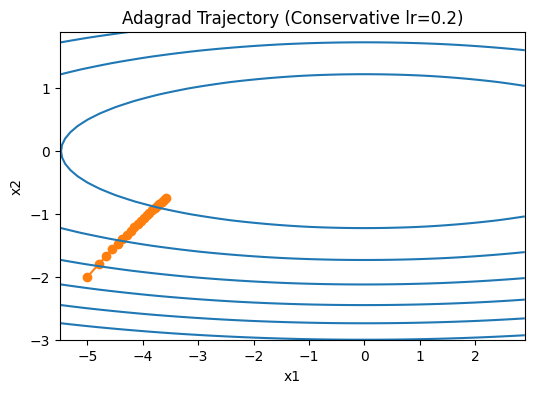

```
Training with lr = 3.0...
```

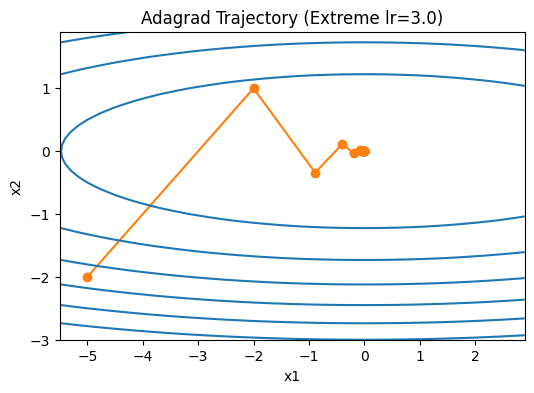

```python
# Experiment 1: Conservative Learning Rate (lr=0.2)
results_small = train_2d_adagrad(lr=0.2)
show_trace_2d(f_2d, results_small, "Adagrad Trajectory (Conservative lr=0.2)")

# Experiment 2: Extreme Learning Rate (lr=3.0)
results_large = train_2d_adagrad(lr=3.0)
show_trace_2d(f_2d, results_large, "Adagrad Trajectory (Extreme lr=3.0)")
```

## 3.4 Concise Implementation

In practice, we use the optimized implementations provided by deep learning frameworks. Below is how to invoke Adagrad using PyTorch's optim module.

```python
import torch.nn as nn

# 1. Define a simple model and loss function
net = nn.Sequential(nn.Linear(2, 1))
loss = nn.MSELoss()

# 2. Initialize Adagrad Optimizer
# We pass the model parameters and the learning rate
trainer = torch.optim.Adagrad(net.parameters(), lr=0.1)

# Example of how to use it in a loop (Pseudo-code for demonstration)
# ------------------------------------------------------------------
# for X, y in data_iter:
#     l = loss(net(X), y)
#     trainer.zero_grad()   # Clear previous gradients
#     l.backward()          # Compute new gradients
#     trainer.step()        # Update parameters using Adagrad logic
# ------------------------------------------------------------------

print(f"Optimizer initialized: {trainer}")
```

```
Optimizer initialized: Adagrad (
Parameter Group 0
    differentiable: False
    eps: 1e-10
    foreach: None
    fused: None
    initial_accumulator_value: 0
    lr: 0.1
    lr_decay: 0
    maximize: False
    weight_decay: 0
)
```

# SECTION 4: EXERCISES IN DETAIL

## Exercise 1: Proof of Norm Preservation

### Problem Statement

**Prove that for an orthogonal matrix $\mathbf{U}$ and vectors $\mathbf{c}, \boldsymbol{\delta}$:** $$\|\mathbf{c} - \boldsymbol{\delta}\|_2 = \|\mathbf{U}\mathbf{c} - \mathbf{U}\boldsymbol{\delta}\|_2$$

Why does this mean that the magnitude of perturbations does not change after an orthogonal change of variables?

### Proof Derivation

To prove the equality, we analyze the squared Euclidean norm of the transformed difference.

**1. Expansion to Quadratic Form:**

First, we express the squared norm using the inner product notation. Recall that $\|\mathbf{x}\|^2 = \mathbf{x}^\top \mathbf{x}$. Applying this to the right-hand side:

$$\|\mathbf{U}\mathbf{c} - \mathbf{U}\boldsymbol{\delta}\|^2 = (\mathbf{U}\mathbf{c} - \mathbf{U}\boldsymbol{\delta})^\top (\mathbf{U}\mathbf{c} - \mathbf{U}\boldsymbol{\delta})$$

**2. Factorization and Transpose:**

We can factor out the matrix $\mathbf{U}$ from the difference terms: $\mathbf{U}\mathbf{c} - \mathbf{U}\boldsymbol{\delta} = \mathbf{U}(\mathbf{c} - \boldsymbol{\delta})$. Substituting this back and applying the transpose property $(\mathbf{AB})^\top = \mathbf{B}^\top \mathbf{A}^\top$:

$$ \begin{aligned} \|\mathbf{U}\mathbf{c} - \mathbf{U}\boldsymbol{\delta}\|^2 &= (\mathbf{U}(\mathbf{c} - \boldsymbol{\delta}))^\top (\mathbf{U}(\mathbf{c} - \boldsymbol{\delta})) \\ &= (\mathbf{c} - \boldsymbol{\delta})^\top \mathbf{U}^\top \mathbf{U} (\mathbf{c} - \boldsymbol{\delta}) \end{aligned} $$

**3. Applying Orthogonality:**

Since $\mathbf{U}$ is an orthogonal matrix, by definition $\mathbf{U}^\top \mathbf{U} = \mathbf{I}$ (Identity matrix). The equation simplifies significantly:

$$(\mathbf{c} - \boldsymbol{\delta})^\top \mathbf{I} (\mathbf{c} - \boldsymbol{\delta}) = (\mathbf{c} - \boldsymbol{\delta})^\top (\mathbf{c} - \boldsymbol{\delta})$$

**4. Conclusion:**

Recognizing that $(\mathbf{c} - \boldsymbol{\delta})^\top (\mathbf{c} - \boldsymbol{\delta})$ is exactly the definition of $\|\mathbf{c} - \boldsymbol{\delta}\|^2$, we have derived:

$$\|\mathbf{U}\mathbf{c} - \mathbf{U}\boldsymbol{\delta}\|^2 = \|\mathbf{c} - \boldsymbol{\delta}\|^2$$

Taking the square root of both sides completes the proof: $$\|\mathbf{U}\mathbf{c} - \mathbf{U}\boldsymbol{\delta}\|_2 = \|\mathbf{c} - \boldsymbol{\delta}\|_2$$

### Interpretation: Stability of Perturbations

The result above leads to a crucial insight in linear algebra and signal processing:

- **Geometry Preservation:** Orthogonal matrices (representing rotations or reflections) preserve the Euclidean distance. Transforming the space with $\mathbf{U}$ does not stretch or shrink the relative distance between vectors.
- **Noise Stability:** If we consider $\boldsymbol{\delta}$ as a **perturbation** or **noise vector** added to the signal $\mathbf{c}$, the proof shows that the magnitude (energy) of this noise remains unchanged after transformation.
- **Application:** This property is vital in methods like **PCA** or **SVD**, ensuring that performing a change of basis does not artificially amplify or suppress the noise/error in the data.

## Exercise 2: Try out Adagrad for an Axis-aligned Function and a Rotated Function

### Problem Statement

**Try out Adagrad for the following objective functions:**

1. **Axis-aligned function:** $$f(\mathbf{x}) = 0.1x_1^2 + 2x_2^2$$
2. **Rotated function (by 45 degrees):** $$f(\mathbf{x}) = 0.1(x_1 + x_2)^2 + 2(x_1 - x_2)^2$$

**Question:** Does it behave differently?

**Answer:** This content has been presented in **Section 3.1**.

## Exercise 5: Adagrad on LeNet (Fashion-MNIST)

We train the improved LeNet-5 architecture using the Adagrad optimizer on the Fashion-MNIST dataset.

- Model: Improved LeNet-5 (replaced Sigmoid with ReLU, and AvgPool with MaxPool to mitigate vanishing gradient issues).
- Optimizer: Adagrad with lr=0.01.
- Loss Function: Cross Entropy Loss.

```python
import torch
import torch.nn as nn
import torchvision
import torchvision.transforms as transforms
from torch.utils.data import DataLoader
import matplotlib.pyplot as plt
import time
```

```python
# 1. Setup Device (GPU if available)
device = torch.device("cuda" if torch.cuda.is_available() else "cpu")
print(f"Training on device: {device}")
```

```
Training on device: cuda
```

```python
# 2. Load Fashion-MNIST Dataset
transform = transforms.Compose([transforms.ToTensor()])
train_dataset = torchvision.datasets.FashionMNIST(root='./data', train=True,
                                                  transform=transform, download=True)
test_dataset = torchvision.datasets.FashionMNIST(root='./data', train=False,
                                                 transform=transform, download=True)

batch_size = 256
train_loader = DataLoader(dataset=train_dataset, batch_size=batch_size, shuffle=True)
test_loader = DataLoader(dataset=test_dataset, batch_size=batch_size, shuffle=False)
```

```python
# 3. Define Improved LeNet (ReLU + MaxPool)
def get_net():
    return nn.Sequential(
        nn.Conv2d(1, 6, kernel_size=5, padding=2), nn.ReLU(),
        nn.MaxPool2d(kernel_size=2, stride=2),
        nn.Conv2d(6, 16, kernel_size=5), nn.ReLU(),
        nn.MaxPool2d(kernel_size=2, stride=2),
        nn.Flatten(),
        nn.Linear(16 * 5 * 5, 120), nn.ReLU(),
        nn.Linear(120, 84), nn.ReLU(),
        nn.Linear(84, 10)
    ).to(device)
```

```python
# 4. Training Loop Function
def train_and_record(net, optimizer, num_epochs=10, name="Model"):
    criterion = nn.CrossEntropyLoss()
    train_loss_history = []
    test_acc_history = []

    print(f"--- Starting Training: {name} ---")
    start_time = time.time()

    for epoch in range(num_epochs):
        net.train()
        running_loss = 0.0
        for X, y in train_loader:
            X, y = X.to(device), y.to(device)
            optimizer.zero_grad()
            outputs = net(X)
            loss = criterion(outputs, y)
            loss.backward()
            optimizer.step()
            running_loss += loss.item()

        # Evaluate
        net.eval()
        correct, total = 0, 0
        with torch.no_grad():
            for X, y in test_loader:
                X, y = X.to(device), y.to(device)
                outputs = net(X)
                _, predicted = torch.max(outputs.data, 1)
                total += y.size(0)
                correct += (predicted == y).sum().item()

        avg_loss = running_loss / len(train_loader)
        acc = correct / total

        train_loss_history.append(avg_loss)
        test_acc_history.append(acc)

        print(f"Epoch [{epoch+1}/{num_epochs}] Loss: {avg_loss:.4f} | Acc: {acc:.4f}")

    print(f"Total time: {time.time() - start_time:.1f}s\n")
    return train_loss_history, test_acc_history
```

```python
# 5. Visualize Function
def visualize_history(histories, titles, metric_name="Loss"):
    plt.figure(figsize=(8, 5))
    for history, title in zip(histories, titles):
        plt.plot(history, marker='o', label=title)
    plt.xlabel('Epoch')
    plt.ylabel(metric_name)
    plt.title(f'{metric_name} Progression')
    plt.legend()
    plt.grid(True)
    plt.show()
```

```python
# 5. Initialize Optimizer (Adagrad) & Model
net = get_net()
optimizer = torch.optim.Adagrad(net.parameters(), lr=0.01)
```

```
--- Starting Training: Adagrad ---
Epoch [1/10] Loss: 0.8220 | Acc: 0.7542
Epoch [2/10] Loss: 0.5376 | Acc: 0.7906
Epoch [3/10] Loss: 0.4714 | Acc: 0.8318
Epoch [4/10] Loss: 0.4325 | Acc: 0.8380
Epoch [5/10] Loss: 0.4083 | Acc: 0.8507
Epoch [6/10] Loss: 0.3904 | Acc: 0.8487
Epoch [7/10] Loss: 0.3780 | Acc: 0.8552
Epoch [8/10] Loss: 0.3671 | Acc: 0.8551
Epoch [9/10] Loss: 0.3576 | Acc: 0.8610
Epoch [10/10] Loss: 0.3505 | Acc: 0.8672
Total time: 80.4s
```

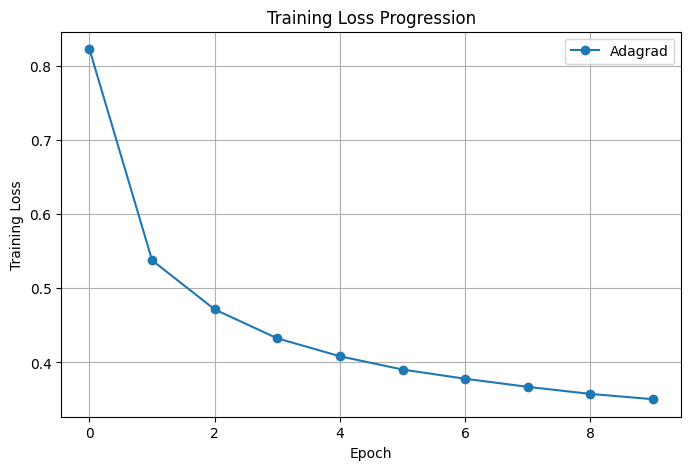

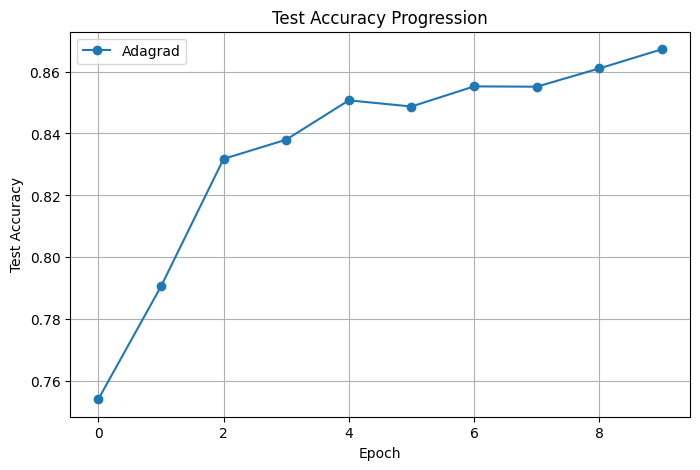

```python
# 6. Run experiment
loss_adagrad, acc_adagrad = train_and_record(net, optimizer, num_epochs=10, name="Adagrad")
visualize_history([loss_adagrad], ["Adagrad"], "Training Loss")
visualize_history([acc_adagrad], ["Adagrad"], "Test Accuracy")
```

## Exercise 6: Modifying Adagrad for Less Aggressive Decay

**Problem Identification:** As observed in quadratic experiment (Section 3.3), Adagrad's state variable $s_t$ accumulates squared gradients indefinitely:

$$s_t = s_{t-1} + g_t^2$$

Because $g_t^2$ is always non-negative, $s_t$ keeps growing. Consequently, the learning rate $\eta / \sqrt{s_t}$ eventually decreases to zero. If this happens too early (before reaching the optimum), the model stops learning.

**Proposed Modification:** To prevent $s_t$ from growing indefinitely, we can replace the full sum with an exponential moving average (EMA). This allows the algorithm to "forget" old gradients and focus on the recent curvature of the loss surface.

**The Modified Update Rule:** Instead of $s_t = s_{t-1} + g_t^2$, we use:

$$s_t \leftarrow \gamma s_{t-1} + (1 - \gamma) g_t^2$$

Where $\gamma$ (typically 0.9) is a decay factor.This ensures that $s_t$ does not grow without bound.The learning rate effectively stabilizes instead of vanishing.

*This specific modification effectively transforms **Adagrad** into the **RMSProp** algorithm. By introducing a "forgetting" factor ($\gamma$), it prevents the learning rate from vanishing. This mechanism is also a foundational component of the **Adam** optimizer, making it highly effective for training deep neural networks.*

```python
net_rmsprop = get_net()
optimizer_rmsprop = torch.optim.RMSprop(net_rmsprop.parameters(), lr=0.01, alpha=0.9)
loss_rmsprop, acc_rmsprop = train_and_record(net_rmsprop, optimizer_rmsprop,
                                             num_epochs=10, name="RMSProp (Modified)")
```

```
--- Starting Training: RMSProp (Modified) ---
Epoch [1/10] Loss: 0.6572 | Acc: 0.8467
Epoch [2/10] Loss: 0.3711 | Acc: 0.8584
Epoch [3/10] Loss: 0.3311 | Acc: 0.8621
Epoch [4/10] Loss: 0.3072 | Acc: 0.8701
Epoch [5/10] Loss: 0.2936 | Acc: 0.8741
Epoch [6/10] Loss: 0.2839 | Acc: 0.8820
Epoch [7/10] Loss: 0.2751 | Acc: 0.8750
Epoch [8/10] Loss: 0.2686 | Acc: 0.8865
Epoch [9/10] Loss: 0.2671 | Acc: 0.8794
Epoch [10/10] Loss: 0.2635 | Acc: 0.8767
Total time: 76.1s
```

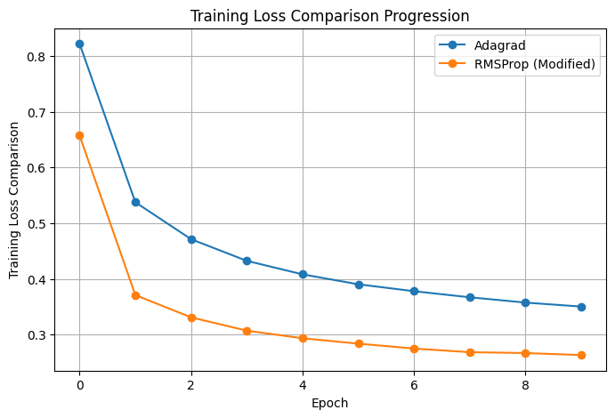

```python
visualize_history([loss_adagrad, loss_rmsprop],
                  ["Adagrad", "RMSProp (Modified)"],
                  "Training Loss Comparison")
```

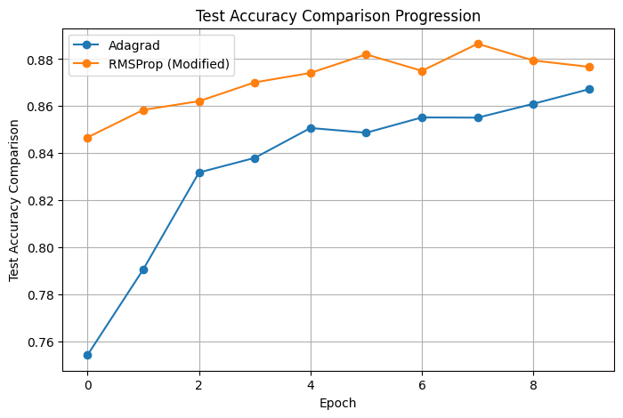

```python
visualize_history([acc_adagrad, acc_rmsprop],
                  ["Adagrad", "RMSProp (Modified)"],
                  "Test Accuracy Comparison")
```